# Lesson 17

Melinda K. Higgins, PhD.

October 24, 2017

## Lesson 17 - Analysis of Covariance (ANCOVA)

In this lesson, we’re working with the `HELP` dataset. We will be using these variables:

- `sexrisk` - dependent variable (DV)
- `mcs` - independent variable (IV)
- `pss_fr` - continuous covariate (CV)
- `female` - discrete/categorical covariate (CV)

Load the initial packages `tidyverse` and `haven` and load the HELP dataset.

Select the variables we want for this lesson:

- DV: `sexrisk`
- IV: `mcs`
- CV: `pss_fr` or `female`

Let’s also recode `female` to `male` by flipping the 0,1 and let’s mean center `mcs` and `pss_fr` since we’ll also look at the interaction between these variables plus the interactions between `mcs` and gender (`female` or `male`).

## Regression Approach

Using a regression approach - look at `pss_fr` as a covariate for the relationship between `sexrisk` and `mcs` adjusting for `pss_fr`. Note the use of `*` which computes the interaction for you.

### regression summary

```
##
## Call:
## lm(formula = sexrisk ~ mcsC * pss_frC, data = help2)
##
## Residuals:
##    Min     1Q Median     3Q    Max
## -5.420 -1.814 -0.228  1.609  9.476
##
## Coefficients:
##               Estimate Std. Error t value Pr(>|t|)
## (Intercept)   4.632164   0.131711  35.169   <2e-16 ***
## mcsC         -0.021117   0.010414  -2.028   0.0432 *
## pss_frC      -0.070871   0.033052  -2.144   0.0326 *
## mcsC:pss_frC  0.001448   0.002471   0.586   0.5580
## ---
## Signif. codes:  0 '***' 0.001 '**' 0.01 '*' 0.05 '.' 0.1 ' ' 1
##
## Residual standard error: 2.779 on 449 degrees of freedom
## Multiple R-squared:  0.02184,    Adjusted R-squared:  0.01531
## F-statistic: 3.342 on 3 and 449 DF,  p-value: 0.0192
```

### `olsrr` regression summary

```
##                         Model Summary
## --------------------------------------------------------------
## R                       0.148       RMSE                2.779
## R-Squared               0.022       Coef. Var          59.854
## Adj. R-Squared          0.015       MSE                 7.721
## Pred R-Squared          0.004       MAE                 2.133
## --------------------------------------------------------------
##  RMSE: Root Mean Square Error
##  MSE: Mean Square Error
##  MAE: Mean Absolute Error
##
##                                ANOVA
## --------------------------------------------------------------------
##                 Sum of
##                Squares         DF    Mean Square      F        Sig.
## --------------------------------------------------------------------
## Regression      77.406          3         25.802    3.342    0.0192
## Residual      3466.660        449          7.721
## Total         3544.066        452
## --------------------------------------------------------------------
##
##                                    Parameter Estimates
## -----------------------------------------------------------------------------------------
##        model      Beta    Std. Error    Std. Beta      t        Sig      lower     upper
## -----------------------------------------------------------------------------------------
##  (Intercept)     4.632         0.132                 35.169    0.000     4.373     4.891
##         mcsC    -0.021         0.010       -0.097    -2.028    0.043    -0.042    -0.001
##      pss_frC    -0.071         0.033       -0.101    -2.144    0.033    -0.136    -0.006
## mcsC:pss_frC     0.001         0.002        0.028     0.586    0.558    -0.003     0.006
## -----------------------------------------------------------------------------------------
```

## Using an ANOVA approach

Let’s run this again using the `aov()` function. Look at usual `summary()` function and the `ols_regress()` function from the `olsrr` package.

```
##               Df Sum Sq Mean Sq F value Pr(>F)
## mcsC           1     40   39.91   5.169 0.0235 *
## pss_frC        1     35   34.85   4.513 0.0342 *
## mcsC:pss_frC   1      3    2.65   0.344 0.5580
## Residuals    449   3467    7.72
## ---
## Signif. codes:  0 '***' 0.001 '**' 0.01 '*' 0.05 '.' 0.1 ' ' 1
```

```
##                         Model Summary
## --------------------------------------------------------------
## R                       0.148       RMSE                2.779
## R-Squared               0.022       Coef. Var          59.854
## Adj. R-Squared          0.015       MSE                 7.721
## Pred R-Squared          0.004       MAE                 2.133
## --------------------------------------------------------------
##  RMSE: Root Mean Square Error
##  MSE: Mean Square Error
##  MAE: Mean Absolute Error
##
##                                ANOVA
## --------------------------------------------------------------------
##                 Sum of
##                Squares         DF    Mean Square      F        Sig.
## --------------------------------------------------------------------
## Regression      77.406          3         25.802    3.342    0.0192
## Residual      3466.660        449          7.721
## Total         3544.066        452
## --------------------------------------------------------------------
##
##                                    Parameter Estimates
## -----------------------------------------------------------------------------------------
##        model      Beta    Std. Error    Std. Beta      t        Sig      lower     upper
## -----------------------------------------------------------------------------------------
##  (Intercept)     4.632         0.132                 35.169    0.000     4.373     4.891
##         mcsC    -0.021         0.010       -0.097    -2.028    0.043    -0.042    -0.001
##      pss_frC    -0.071         0.033       -0.101    -2.144    0.033    -0.136    -0.006
## mcsC:pss_frC     0.001         0.002        0.028     0.586    0.558    -0.003     0.006
## -----------------------------------------------------------------------------------------
```

## Effect Plots

Let’s also make an effectplot showing the interaction or lack thereof between `mcs` and `pss_fr` for `sexrisk`. For this we will use the `effects` package by John Fox.

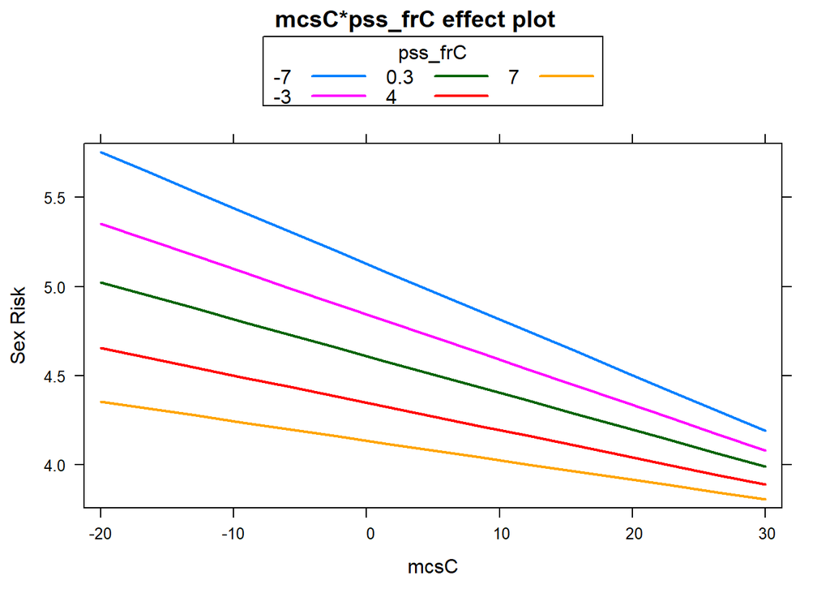

### adjust the y-axis to more reasonable range

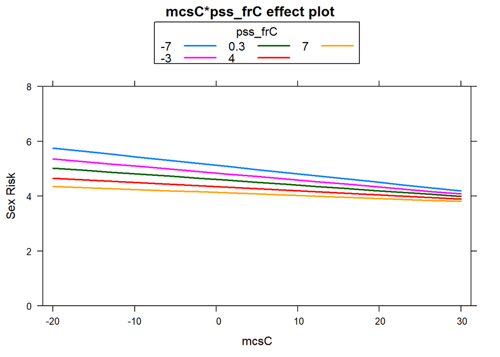

## Consider gender as a covariate

Now, let’s look at gender as a covariate. First, run for `female` and then run for `male`. Knowing which category is coded as 0 and which is coded as 1 changes the interpretation of the intercept but also changes the interpretation of the main effect of `mcs` which is **conditional upon** gender.

### Model for `female` where male=0 and female=1

```
##
## Call:
## lm(formula = sexrisk ~ mcsC * female, data = help2)
##
## Residuals:
##     Min      1Q  Median      3Q     Max
## -6.2586 -1.7155 -0.4406  1.5303  8.8713
##
## Coefficients:
##              Estimate Std. Error t value Pr(>|t|)
## (Intercept)  4.504974   0.148745  30.287  < 2e-16 ***
## mcsC        -0.005874   0.011549  -0.509  0.61124
## female       0.394433   0.311226   1.267  0.20569
## mcsC:female -0.068420   0.024507  -2.792  0.00546 **
## ---
## Signif. codes:  0 '***' 0.001 '**' 0.01 '*' 0.05 '.' 0.1 ' ' 1
##
## Residual standard error: 2.761 on 449 degrees of freedom
## Multiple R-squared:  0.03435,    Adjusted R-squared:  0.02789
## F-statistic: 5.323 on 3 and 449 DF,  p-value: 0.001301
```

```
##                         Model Summary
## --------------------------------------------------------------
## R                       0.185       RMSE                2.761
## R-Squared               0.034       Coef. Var          59.470
## Adj. R-Squared          0.028       MSE                 7.622
## Pred R-Squared          0.016       MAE                 2.165
## --------------------------------------------------------------
##  RMSE: Root Mean Square Error
##  MSE: Mean Square Error
##  MAE: Mean Absolute Error
##
##                                ANOVA
## --------------------------------------------------------------------
##                 Sum of
##                Squares         DF    Mean Square      F        Sig.
## --------------------------------------------------------------------
## Regression     121.721          3         40.574    5.323    0.0013
## Residual      3422.345        449          7.622
## Total         3544.066        452
## --------------------------------------------------------------------
##
##                                   Parameter Estimates
## ----------------------------------------------------------------------------------------
##       model      Beta    Std. Error    Std. Beta      t        Sig      lower     upper
## ----------------------------------------------------------------------------------------
## (Intercept)     4.505         0.149                 30.287    0.000     4.213     4.797
##        mcsC    -0.006         0.012       -0.027    -0.509    0.611    -0.029     0.017
##      female     0.394         0.311        0.060     1.267    0.206    -0.217     1.006
## mcsC:female    -0.068         0.025       -0.150    -2.792    0.005    -0.117    -0.020
## ----------------------------------------------------------------------------------------
```

### Model for `male` where male=1 and female=0

```
##
## Call:
## lm(formula = sexrisk ~ mcsC * male, data = help2)
##
## Residuals:
##     Min      1Q  Median      3Q     Max
## -6.2586 -1.7155 -0.4406  1.5303  8.8713
##
## Coefficients:
##             Estimate Std. Error t value Pr(>|t|)
## (Intercept)  4.89941    0.27338  17.922  < 2e-16 ***
## mcsC        -0.07429    0.02161  -3.437 0.000642 ***
## male        -0.39443    0.31123  -1.267 0.205686
## mcsC:male    0.06842    0.02451   2.792 0.005464 **
## ---
## Signif. codes:  0 '***' 0.001 '**' 0.01 '*' 0.05 '.' 0.1 ' ' 1
##
## Residual standard error: 2.761 on 449 degrees of freedom
## Multiple R-squared:  0.03435,    Adjusted R-squared:  0.02789
## F-statistic: 5.323 on 3 and 449 DF,  p-value: 0.001301
```

```
##                         Model Summary
## --------------------------------------------------------------
## R                       0.185       RMSE                2.761
## R-Squared               0.034       Coef. Var          59.470
## Adj. R-Squared          0.028       MSE                 7.622
## Pred R-Squared          0.016       MAE                 2.165
## --------------------------------------------------------------
##  RMSE: Root Mean Square Error
##  MSE: Mean Square Error
##  MAE: Mean Absolute Error
##
##                                ANOVA
## --------------------------------------------------------------------
##                 Sum of
##                Squares         DF    Mean Square      F        Sig.
## --------------------------------------------------------------------
## Regression     121.721          3         40.574    5.323    0.0013
## Residual      3422.345        449          7.622
## Total         3544.066        452
## --------------------------------------------------------------------
##
##                                   Parameter Estimates
## ----------------------------------------------------------------------------------------
##       model      Beta    Std. Error    Std. Beta      t        Sig      lower     upper
## ----------------------------------------------------------------------------------------
## (Intercept)     4.899         0.273                 17.922    0.000     4.362     5.437
##        mcsC    -0.074         0.022       -0.341    -3.437    0.001    -0.117    -0.032
##        male    -0.394         0.311       -0.060    -1.267    0.206    -1.006     0.217
##   mcsC:male     0.068         0.025        0.275     2.792    0.005     0.020     0.117
## ----------------------------------------------------------------------------------------
```

## Run gender as a covariate using the `aov()` function

### ANCOVA using `female` variable

```
##              Df Sum Sq Mean Sq F value  Pr(>F)
## mcsC          1     40   39.91   5.236 0.02259 *
## female        1     22   22.40   2.939 0.08715 .
## mcsC:female   1     59   59.41   7.795 0.00546 **
## Residuals   449   3422    7.62
## ---
## Signif. codes:  0 '***' 0.001 '**' 0.01 '*' 0.05 '.' 0.1 ' ' 1
```

```
##                         Model Summary
## --------------------------------------------------------------
## R                       0.185       RMSE                2.761
## R-Squared               0.034       Coef. Var          59.470
## Adj. R-Squared          0.028       MSE                 7.622
## Pred R-Squared          0.016       MAE                 2.165
## --------------------------------------------------------------
##  RMSE: Root Mean Square Error
##  MSE: Mean Square Error
##  MAE: Mean Absolute Error
##
##                                ANOVA
## --------------------------------------------------------------------
##                 Sum of
##                Squares         DF    Mean Square      F        Sig.
## --------------------------------------------------------------------
## Regression     121.721          3         40.574    5.323    0.0013
## Residual      3422.345        449          7.622
## Total         3544.066        452
## --------------------------------------------------------------------
##
##                                   Parameter Estimates
## ----------------------------------------------------------------------------------------
##       model      Beta    Std. Error    Std. Beta      t        Sig      lower     upper
## ----------------------------------------------------------------------------------------
## (Intercept)     4.505         0.149                 30.287    0.000     4.213     4.797
##        mcsC    -0.006         0.012       -0.027    -0.509    0.611    -0.029     0.017
##      female     0.394         0.311        0.060     1.267    0.206    -0.217     1.006
## mcsC:female    -0.068         0.025       -0.150    -2.792    0.005    -0.117    -0.020
## ----------------------------------------------------------------------------------------
```

### Check type III SS using Anova() from car package

```
## Anova Table (Type III tests)
##
## Response: sexrisk
##             Sum Sq  Df  F value    Pr(>F)
## (Intercept) 6991.7   1 917.2810 < 2.2e-16 ***
## mcsC           2.0   1   0.2587  0.611242
## female        12.2   1   1.6062  0.205686
## mcsC:female   59.4   1   7.7947  0.005464 **
## Residuals   3422.3 449
## ---
## Signif. codes:  0 '***' 0.001 '**' 0.01 '*' 0.05 '.' 0.1 ' ' 1
```

### ANCOVA using `male` variable

```
## Anova Table (Type III tests)
##
## Response: sexrisk
##             Sum Sq  Df  F value    Pr(>F)
## (Intercept) 2448.1   1 321.1834 < 2.2e-16 ***
## mcsC          90.1   1  11.8145 0.0006424 ***
## male          12.2   1   1.6062 0.2056861
## mcsC:male     59.4   1   7.7947 0.0054635 **
## Residuals   3422.3 449
## ---
## Signif. codes:  0 '***' 0.001 '**' 0.01 '*' 0.05 '.' 0.1 ' ' 1
```

## Other packages for plotting interaction effects

Let’s look at a couple more packages for plotting interaction effects:

- `HH` package
- `ggplot2` package
- `sjPlot` package

### Using the `HH` package to run `ANCOVA` and associated plot

Note: to use the `ancova()` function in the `HH` package, the categorical variable `female` must be of factor class. So, I created a new variable `femaleF` which is now a `factor` class.

```
## [1] "labelled"
```

```
## [1] "factor"
```

```
## Analysis of Variance Table
##
## Response: sexrisk
##               Df Sum Sq Mean Sq F value   Pr(>F)
## mcsC           1   39.9  39.907  5.2356 0.022593 *
## femaleF        1   22.4  22.402  2.9391 0.087151 .
## mcsC:femaleF   1   59.4  59.412  7.7947 0.005464 **
## Residuals    449 3422.3   7.622
## ---
## Signif. codes:  0 '***' 0.001 '**' 0.01 '*' 0.05 '.' 0.1 ' ' 1
```

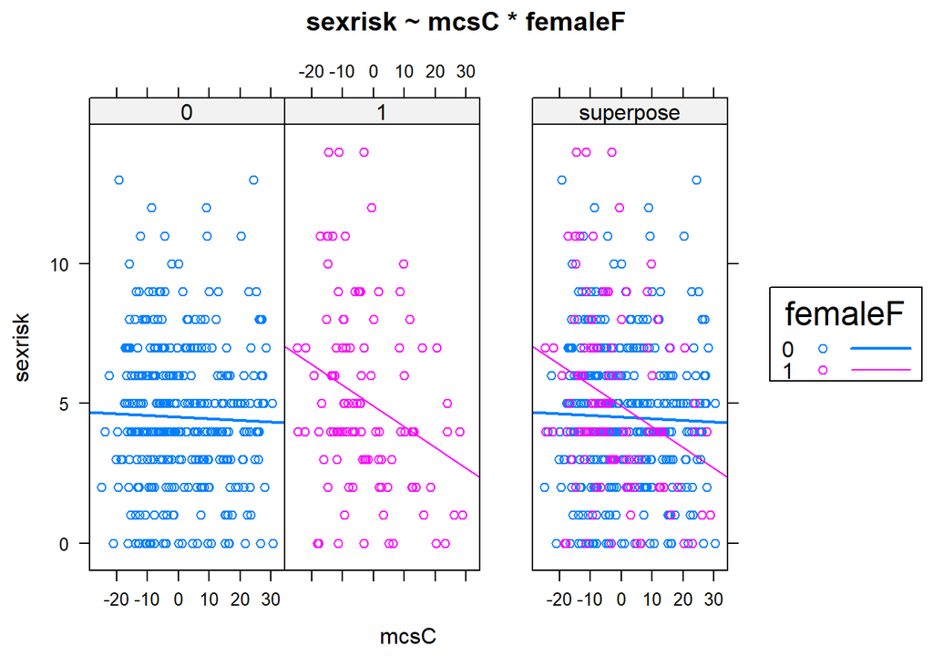

### Using the `ggplot2` package to visualize interaction effects

Note: This plot can also be done using `qplot()` from the `ggplot2` package with an overlay of a smooth regression fit line.

Note: `ggplot2` should already be loaded when we loaded the `tidyverse` package above

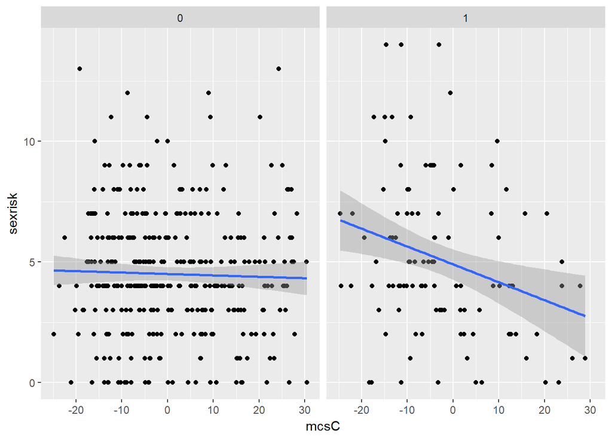

### Using the `sjPlot` package to make interaction plots

Learn more about the `sjPlot` pacakge and specifically the `sjp.int()` function at http://www.strengejacke.de/sjPlot/sjp.int/

**NOTICE** `sjPlot` is using the labels from the “codebook” applied and in use when we read the dataset in using the `tidyverse` compatible `haven` package.

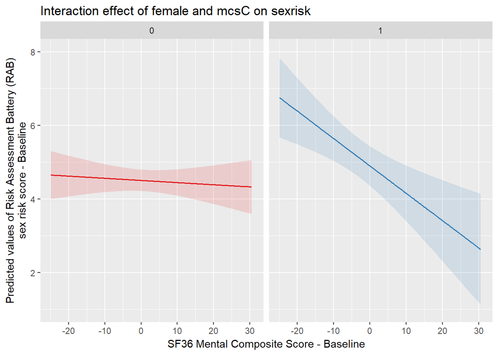